# Risk Factor Analysis

## Outcome Variable

**Outcome Variable:** ever_stunted

## Predictor Variables

**Intervention Variable:** single

**Adjustment Set:**

- arm
- W_mage
- meducyrs
- feducyrs
- W_mhtcm
- W_mwtkg
- W_mbmi
- delta_W_mage
- delta_meducyrs
- delta_feducyrs
- delta_W_mhtcm
- delta_W_mwtkg
- delta_W_mbmi

## Stratifying Variables

The analysis was stratified on these variable(s):

- agecat
- studyid
- country

## Data Summary

| agecat | studyid | country | single | ever_stunted | n_cell | n |
| --- | --- | --- | --- | --- | --- | --- |
| 0-24 months | ki0047075b-MAL-ED | BANGLADESH | 0 | 0 | 104 | 265 |
| 0-24 months | ki0047075b-MAL-ED | BANGLADESH | 0 | 1 | 161 | 265 |
| 0-24 months | ki0047075b-MAL-ED | BANGLADESH | 1 | 0 | 0 | 265 |
| 0-24 months | ki0047075b-MAL-ED | BANGLADESH | 1 | 1 | 0 | 265 |
| 0-24 months | ki0047075b-MAL-ED | BRAZIL | 0 | 0 | 154 | 233 |
| 0-24 months | ki0047075b-MAL-ED | BRAZIL | 0 | 1 | 43 | 233 |
| 0-24 months | ki0047075b-MAL-ED | BRAZIL | 1 | 0 | 25 | 233 |
| 0-24 months | ki0047075b-MAL-ED | BRAZIL | 1 | 1 | 11 | 233 |
| 0-24 months | ki0047075b-MAL-ED | INDIA | 0 | 0 | 101 | 249 |
| 0-24 months | ki0047075b-MAL-ED | INDIA | 0 | 1 | 148 | 249 |
| 0-24 months | ki0047075b-MAL-ED | INDIA | 1 | 0 | 0 | 249 |
| 0-24 months | ki0047075b-MAL-ED | INDIA | 1 | 1 | 0 | 249 |
| 0-24 months | ki0047075b-MAL-ED | NEPAL | 0 | 0 | 157 | 240 |
| 0-24 months | ki0047075b-MAL-ED | NEPAL | 0 | 1 | 83 | 240 |
| 0-24 months | ki0047075b-MAL-ED | NEPAL | 1 | 0 | 0 | 240 |
| 0-24 months | ki0047075b-MAL-ED | NEPAL | 1 | 1 | 0 | 240 |
| 0-24 months | ki0047075b-MAL-ED | PERU | 0 | 0 | 101 | 303 |
| 0-24 months | ki0047075b-MAL-ED | PERU | 0 | 1 | 167 | 303 |
| 0-24 months | ki0047075b-MAL-ED | PERU | 1 | 0 | 14 | 303 |
| 0-24 months | ki0047075b-MAL-ED | PERU | 1 | 1 | 21 | 303 |
| 0-24 months | ki0047075b-MAL-ED | SOUTH AFRICA | 0 | 0 | 82 | 314 |
| 0-24 months | ki0047075b-MAL-ED | SOUTH AFRICA | 0 | 1 | 94 | 314 |
| 0-24 months | ki0047075b-MAL-ED | SOUTH AFRICA | 1 | 0 | 61 | 314 |
| 0-24 months | ki0047075b-MAL-ED | SOUTH AFRICA | 1 | 1 | 77 | 314 |
| 0-24 months | ki0047075b-MAL-ED | TANZANIA, UNITED REPUBLIC OF | 0 | 0 | 38 | 262 |
| 0-24 months | ki0047075b-MAL-ED | TANZANIA, UNITED REPUBLIC OF | 0 | 1 | 214 | 262 |
| 0-24 months | ki0047075b-MAL-ED | TANZANIA, UNITED REPUBLIC OF | 1 | 0 | 3 | 262 |
| 0-24 months | ki0047075b-MAL-ED | TANZANIA, UNITED REPUBLIC OF | 1 | 1 | 7 | 262 |
| 0-24 months | ki1066203-TanzaniaChild2 | TANZANIA, UNITED REPUBLIC OF | 0 | 0 | 1400 | 2375 |
| 0-24 months | ki1066203-TanzaniaChild2 | TANZANIA, UNITED REPUBLIC OF | 0 | 1 | 751 | 2375 |

[output cut: 138 more lines]

The following strata were considered:

- agecat: 0-24 months, studyid: ki0047075b-MAL-ED, country: BANGLADESH
- agecat: 0-24 months, studyid: ki0047075b-MAL-ED, country: BRAZIL
- agecat: 0-24 months, studyid: ki0047075b-MAL-ED, country: INDIA
- agecat: 0-24 months, studyid: ki0047075b-MAL-ED, country: NEPAL
- agecat: 0-24 months, studyid: ki0047075b-MAL-ED, country: PERU
- agecat: 0-24 months, studyid: ki0047075b-MAL-ED, country: SOUTH AFRICA
- agecat: 0-24 months, studyid: ki0047075b-MAL-ED, country: TANZANIA, UNITED REPUBLIC OF
- agecat: 0-24 months, studyid: ki1066203-TanzaniaChild2, country: TANZANIA, UNITED REPUBLIC OF
- agecat: 0-24 months, studyid: ki1112895-Guatemala BSC, country: GUATEMALA
- agecat: 0-24 months, studyid: ki1119695-PROBIT, country: BELARUS
- agecat: 0-24 months, studyid: ki1126311-ZVITAMBO, country: ZIMBABWE
- agecat: 0-24 months, studyid: ki1135781-COHORTS, country: GUATEMALA
- agecat: 0-24 months, studyid: ki1135781-COHORTS, country: INDIA
- agecat: 0-24 months, studyid: ki1135781-COHORTS, country: PHILIPPINES
- agecat: 0-6 months, studyid: ki0047075b-MAL-ED, country: BANGLADESH
- agecat: 0-6 months, studyid: ki0047075b-MAL-ED, country: BRAZIL
- agecat: 0-6 months, studyid: ki0047075b-MAL-ED, country: INDIA
- agecat: 0-6 months, studyid: ki0047075b-MAL-ED, country: NEPAL
- agecat: 0-6 months, studyid: ki0047075b-MAL-ED, country: PERU
- agecat: 0-6 months, studyid: ki0047075b-MAL-ED, country: SOUTH AFRICA
- agecat: 0-6 months, studyid: ki0047075b-MAL-ED, country: TANZANIA, UNITED REPUBLIC OF
- agecat: 0-6 months, studyid: ki1066203-TanzaniaChild2, country: TANZANIA, UNITED REPUBLIC OF
- agecat: 0-6 months, studyid: ki1112895-Guatemala BSC, country: GUATEMALA
- agecat: 0-6 months, studyid: ki1119695-PROBIT, country: BELARUS
- agecat: 0-6 months, studyid: ki1126311-ZVITAMBO, country: ZIMBABWE
- agecat: 0-6 months, studyid: ki1135781-COHORTS, country: GUATEMALA
- agecat: 0-6 months, studyid: ki1135781-COHORTS, country: INDIA
- agecat: 0-6 months, studyid: ki1135781-COHORTS, country: PHILIPPINES
- agecat: 6-24 months, studyid: ki0047075b-MAL-ED, country: BANGLADESH
- agecat: 6-24 months, studyid: ki0047075b-MAL-ED, country: BRAZIL
- agecat: 6-24 months, studyid: ki0047075b-MAL-ED, country: INDIA
- agecat: 6-24 months, studyid: ki0047075b-MAL-ED, country: NEPAL
- agecat: 6-24 months, studyid: ki0047075b-MAL-ED, country: PERU
- agecat: 6-24 months, studyid: ki0047075b-MAL-ED, country: SOUTH AFRICA
- agecat: 6-24 months, studyid: ki0047075b-MAL-ED, country: TANZANIA, UNITED REPUBLIC OF
- agecat: 6-24 months, studyid: ki1066203-TanzaniaChild2, country: TANZANIA, UNITED REPUBLIC OF
- agecat: 6-24 months, studyid: ki1112895-Guatemala BSC, country: GUATEMALA
- agecat: 6-24 months, studyid: ki1119695-PROBIT, country: BELARUS
- agecat: 6-24 months, studyid: ki1126311-ZVITAMBO, country: ZIMBABWE
- agecat: 6-24 months, studyid: ki1135781-COHORTS, country: GUATEMALA
- agecat: 6-24 months, studyid: ki1135781-COHORTS, country: INDIA
- agecat: 6-24 months, studyid: ki1135781-COHORTS, country: PHILIPPINES

### Dropped Strata

Some strata were dropped due to rare outcomes:

- agecat: 0-24 months, studyid: ki0047075b-MAL-ED, country: BANGLADESH
- agecat: 0-24 months, studyid: ki0047075b-MAL-ED, country: INDIA
- agecat: 0-24 months, studyid: ki0047075b-MAL-ED, country: NEPAL
- agecat: 0-24 months, studyid: ki0047075b-MAL-ED, country: TANZANIA, UNITED REPUBLIC OF
- agecat: 0-24 months, studyid: ki1135781-COHORTS, country: INDIA
- agecat: 0-6 months, studyid: ki0047075b-MAL-ED, country: BANGLADESH
- agecat: 0-6 months, studyid: ki0047075b-MAL-ED, country: INDIA
- agecat: 0-6 months, studyid: ki0047075b-MAL-ED, country: NEPAL
- agecat: 0-6 months, studyid: ki0047075b-MAL-ED, country: TANZANIA, UNITED REPUBLIC OF
- agecat: 0-6 months, studyid: ki1135781-COHORTS, country: INDIA
- agecat: 6-24 months, studyid: ki0047075b-MAL-ED, country: BANGLADESH
- agecat: 6-24 months, studyid: ki0047075b-MAL-ED, country: BRAZIL
- agecat: 6-24 months, studyid: ki0047075b-MAL-ED, country: INDIA
- agecat: 6-24 months, studyid: ki0047075b-MAL-ED, country: NEPAL
- agecat: 6-24 months, studyid: ki0047075b-MAL-ED, country: TANZANIA, UNITED REPUBLIC OF
- agecat: 6-24 months, studyid: ki1135781-COHORTS, country: INDIA

## Methods Detail

We’re interested in the causal parameters $E[Y_a]$ for all values of $a \in \mathcal{A}$. These parameters represent the mean outcome if, possibly contrary to fact, we intervened to set all units to have $A=a$. Under the randomization and positivity assumptions, these are identified by the statistical parameters $\psi_a=E_W[E_{Y|A,W}(Y|A=a,W)]$. In addition, we’re interested in the mean of $Y$, $E[Y]$ under no intervention (the observed mean). We will estimate these parameters by using SuperLearner to fit the relevant likelihood factors – $E_{Y|A,W}(Y|A=a,W)$ and $p(A=a|W)$, and then updating our likelihood fit using a joint TMLE.

For unadjusted analyses ($W=\{\}$), initial likelihoods were estimated using Lrnr_glm to estimate the simple $E(Y|A)$ and Lrnr_mean to estimate $p(A)$. For adjusted analyses, a small library containing Lrnr_glmnet, Lrnr_xgboost, and Lrnr_mean was used.

Having estimated these parameters, we will then use the delta method to estimate relative risks and attributable risks relative to a prespecified baseline level of $A$.

# Results Detail

## Results Plots

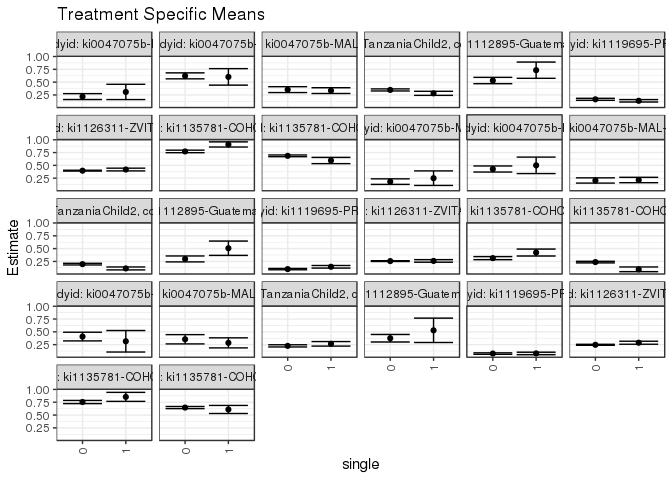

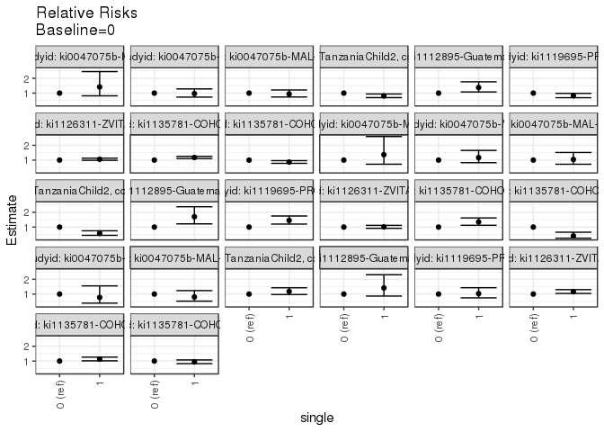

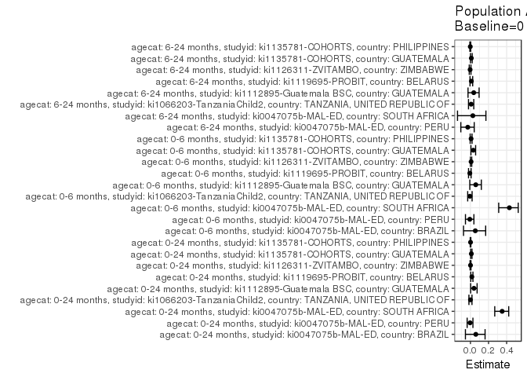

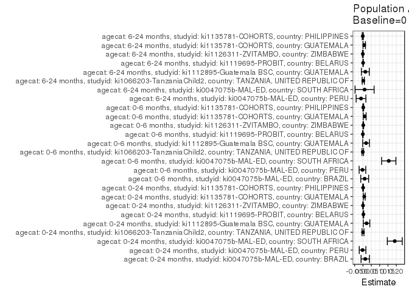

## Results Table

### Parameter: TSM

| agecat | studyid | country | intervention_level | baseline_level | estimate | ci_lower | ci_upper |
| --- | --- | --- | --- | --- | --- | --- | --- |
| 0-24 months | ki0047075b-MAL-ED | BRAZIL | 0 | NA | 0.2179836 | 0.1604045 | 0.2755627 |
| 0-24 months | ki0047075b-MAL-ED | BRAZIL | 1 | NA | 0.3087629 | 0.1594816 | 0.4580443 |
| 0-24 months | ki0047075b-MAL-ED | PERU | 0 | NA | 0.6228628 | 0.5647922 | 0.6809333 |
| 0-24 months | ki0047075b-MAL-ED | PERU | 1 | NA | 0.6025518 | 0.4416303 | 0.7634732 |
| 0-24 months | ki0047075b-MAL-ED | SOUTH AFRICA | 0 | NA | 0.3538044 | 0.2964458 | 0.4111631 |
| 0-24 months | ki0047075b-MAL-ED | SOUTH AFRICA | 1 | NA | 0.3344316 | 0.2782142 | 0.3906491 |
| 0-24 months | ki1066203-TanzaniaChild2 | TANZANIA, UNITED REPUBLIC OF | 0 | NA | 0.3481043 | 0.3281481 | 0.3680604 |
| 0-24 months | ki1066203-TanzaniaChild2 | TANZANIA, UNITED REPUBLIC OF | 1 | NA | 0.2816801 | 0.2420324 | 0.3213278 |
| 0-24 months | ki1112895-Guatemala BSC | GUATEMALA | 0 | NA | 0.5317460 | 0.4700280 | 0.5934641 |
| 0-24 months | ki1112895-Guatemala BSC | GUATEMALA | 1 | NA | 0.7333333 | 0.5748097 | 0.8918569 |
| 0-24 months | ki1119695-PROBIT | BELARUS | 0 | NA | 0.1648335 | 0.1456091 | 0.1840579 |
| 0-24 months | ki1119695-PROBIT | BELARUS | 1 | NA | 0.1357759 | 0.1122652 | 0.1592866 |
| 0-24 months | ki1126311-ZVITAMBO | ZIMBABWE | 0 | NA | 0.3963803 | 0.3880675 | 0.4046932 |
| 0-24 months | ki1126311-ZVITAMBO | ZIMBABWE | 1 | NA | 0.4188081 | 0.3918639 | 0.4457523 |
| 0-24 months | ki1135781-COHORTS | GUATEMALA | 0 | NA | 0.7718126 | 0.7471377 | 0.7964875 |
| 0-24 months | ki1135781-COHORTS | GUATEMALA | 1 | NA | 0.9081650 | 0.8575951 | 0.9587349 |
| 0-24 months | ki1135781-COHORTS | PHILIPPINES | 0 | NA | 0.6861130 | 0.6693530 | 0.7028731 |
| 0-24 months | ki1135781-COHORTS | PHILIPPINES | 1 | NA | 0.5947995 | 0.5342838 | 0.6553152 |
| 0-6 months | ki0047075b-MAL-ED | BRAZIL | 0 | NA | 0.1827411 | 0.1286598 | 0.2368224 |
| 0-6 months | ki0047075b-MAL-ED | BRAZIL | 1 | NA | 0.2500000 | 0.1082473 | 0.3917527 |
| 0-6 months | ki0047075b-MAL-ED | PERU | 0 | NA | 0.4288033 | 0.3695791 | 0.4880275 |
| 0-6 months | ki0047075b-MAL-ED | PERU | 1 | NA | 0.5007642 | 0.3403780 | 0.6611504 |
| 0-6 months | ki0047075b-MAL-ED | SOUTH AFRICA | 0 | NA | 0.2050038 | 0.1536095 | 0.2563981 |
| 0-6 months | ki0047075b-MAL-ED | SOUTH AFRICA | 1 | NA | 0.2140696 | 0.1614970 | 0.2666422 |
| 0-6 months | ki1066203-TanzaniaChild2 | TANZANIA, UNITED REPUBLIC OF | 0 | NA | 0.1968823 | 0.1802454 | 0.2135193 |
| 0-6 months | ki1066203-TanzaniaChild2 | TANZANIA, UNITED REPUBLIC OF | 1 | NA | 0.1132067 | 0.0844137 | 0.1419997 |
| 0-6 months | ki1112895-Guatemala BSC | GUATEMALA | 0 | NA | 0.2983121 | 0.2403454 | 0.3562789 |
| 0-6 months | ki1112895-Guatemala BSC | GUATEMALA | 1 | NA | 0.5071688 | 0.3674272 | 0.6469104 |
| 0-6 months | ki1119695-PROBIT | BELARUS | 0 | NA | 0.1001644 | 0.0871572 | 0.1131716 |
| 0-6 months | ki1119695-PROBIT | BELARUS | 1 | NA | 0.1453751 | 0.1202619 | 0.1704882 |
| 0-6 months | ki1126311-ZVITAMBO | ZIMBABWE | 0 | NA | 0.2562739 | 0.2488404 | 0.2637073 |
| 0-6 months | ki1126311-ZVITAMBO | ZIMBABWE | 1 | NA | 0.2593322 | 0.2347959 | 0.2838685 |
| 0-6 months | ki1135781-COHORTS | GUATEMALA | 0 | NA | 0.3141249 | 0.2841084 | 0.3441414 |
| 0-6 months | ki1135781-COHORTS | GUATEMALA | 1 | NA | 0.4233615 | 0.3557613 | 0.4909618 |
| 0-6 months | ki1135781-COHORTS | PHILIPPINES | 0 | NA | 0.2368098 | 0.2214601 | 0.2521596 |
| 0-6 months | ki1135781-COHORTS | PHILIPPINES | 1 | NA | 0.0955091 | 0.0497696 | 0.1412486 |
| 6-24 months | ki0047075b-MAL-ED | PERU | 0 | NA | 0.4076923 | 0.3229347 | 0.4924499 |
| 6-24 months | ki0047075b-MAL-ED | PERU | 1 | NA | 0.3157895 | 0.1060755 | 0.5255034 |
| 6-24 months | ki0047075b-MAL-ED | SOUTH AFRICA | 0 | NA | 0.3550323 | 0.2646640 | 0.4454005 |
| 6-24 months | ki0047075b-MAL-ED | SOUTH AFRICA | 1 | NA | 0.2851294 | 0.1869125 | 0.3833463 |
| 6-24 months | ki1066203-TanzaniaChild2 | TANZANIA, UNITED REPUBLIC OF | 0 | NA | 0.2259422 | 0.2045429 | 0.2473415 |
| 6-24 months | ki1066203-TanzaniaChild2 | TANZANIA, UNITED REPUBLIC OF | 1 | NA | 0.2657862 | 0.2214188 | 0.3101537 |
| 6-24 months | ki1112895-Guatemala BSC | GUATEMALA | 0 | NA | 0.3750000 | 0.3015949 | 0.4484051 |
| 6-24 months | ki1112895-Guatemala BSC | GUATEMALA | 1 | NA | 0.5294118 | 0.2914989 | 0.7673246 |
| 6-24 months | ki1119695-PROBIT | BELARUS | 0 | NA | 0.0760750 | 0.0619741 | 0.0901758 |
| 6-24 months | ki1119695-PROBIT | BELARUS | 1 | NA | 0.0784057 | 0.0544047 | 0.1024066 |
| 6-24 months | ki1126311-ZVITAMBO | ZIMBABWE | 0 | NA | 0.2467606 | 0.2370524 | 0.2564688 |
| 6-24 months | ki1126311-ZVITAMBO | ZIMBABWE | 1 | NA | 0.2873550 | 0.2577770 | 0.3169329 |
| 6-24 months | ki1135781-COHORTS | GUATEMALA | 0 | NA | 0.7546174 | 0.7239651 | 0.7852698 |
| 6-24 months | ki1135781-COHORTS | GUATEMALA | 1 | NA | 0.8548387 | 0.7671013 | 0.9425761 |
| 6-24 months | ki1135781-COHORTS | PHILIPPINES | 0 | NA | 0.6462696 | 0.6255548 | 0.6669844 |
| 6-24 months | ki1135781-COHORTS | PHILIPPINES | 1 | NA | 0.6091000 | 0.5306565 | 0.6875435 |

### Parameter: E(Y)

| agecat | studyid | country | intervention_level | baseline_level | estimate | ci_lower | ci_upper |
| --- | --- | --- | --- | --- | --- | --- | --- |
| 0-24 months | ki0047075b-MAL-ED | BRAZIL | NA | NA | 0.2317597 | 0.1774632 | 0.2860561 |
| 0-24 months | ki0047075b-MAL-ED | PERU | NA | NA | 0.6204620 | 0.5657315 | 0.6751926 |
| 0-24 months | ki0047075b-MAL-ED | SOUTH AFRICA | NA | NA | 0.5445860 | 0.4894148 | 0.5997572 |
| 0-24 months | ki1066203-TanzaniaChild2 | TANZANIA, UNITED REPUBLIC OF | NA | NA | 0.3482105 | 0.3290467 | 0.3673744 |
| 0-24 months | ki1112895-Guatemala BSC | GUATEMALA | NA | NA | 0.5531915 | 0.4950624 | 0.6113206 |
| 0-24 months | ki1119695-PROBIT | BELARUS | NA | NA | 0.1674854 | 0.1488048 | 0.1861659 |
| 0-24 months | ki1126311-ZVITAMBO | ZIMBABWE | NA | NA | 0.3967178 | 0.3886181 | 0.4048175 |
| 0-24 months | ki1135781-COHORTS | GUATEMALA | NA | NA | 0.7796189 | 0.7562250 | 0.8030128 |
| 0-24 months | ki1135781-COHORTS | PHILIPPINES | NA | NA | 0.6868787 | 0.6703303 | 0.7034272 |
| 0-6 months | ki0047075b-MAL-ED | BRAZIL | NA | NA | 0.1931330 | 0.1423366 | 0.2439295 |
| 0-6 months | ki0047075b-MAL-ED | PERU | NA | NA | 0.4257426 | 0.3699763 | 0.4815088 |
| 0-6 months | ki0047075b-MAL-ED | SOUTH AFRICA | NA | NA | 0.3598726 | 0.3067005 | 0.4130447 |
| 0-6 months | ki1066203-TanzaniaChild2 | TANZANIA, UNITED REPUBLIC OF | NA | NA | 0.1957895 | 0.1798275 | 0.2117515 |
| 0-6 months | ki1112895-Guatemala BSC | GUATEMALA | NA | NA | 0.3169811 | 0.2608532 | 0.3731091 |
| 0-6 months | ki1119695-PROBIT | BELARUS | NA | NA | 0.0995087 | 0.0864641 | 0.1125533 |
| 0-6 months | ki1126311-ZVITAMBO | ZIMBABWE | NA | NA | 0.2581291 | 0.2508782 | 0.2653799 |
| 0-6 months | ki1135781-COHORTS | GUATEMALA | NA | NA | 0.3244353 | 0.2950189 | 0.3538517 |
| 0-6 months | ki1135781-COHORTS | PHILIPPINES | NA | NA | 0.2385686 | 0.2233602 | 0.2537770 |
| 6-24 months | ki0047075b-MAL-ED | PERU | NA | NA | 0.3959732 | 0.3171819 | 0.4747644 |
| 6-24 months | ki0047075b-MAL-ED | SOUTH AFRICA | NA | NA | 0.3647799 | 0.2897219 | 0.4398379 |
| 6-24 months | ki1066203-TanzaniaChild2 | TANZANIA, UNITED REPUBLIC OF | NA | NA | 0.2278162 | 0.2071874 | 0.2484451 |
| 6-24 months | ki1112895-Guatemala BSC | GUATEMALA | NA | NA | 0.3891892 | 0.3187405 | 0.4596379 |
| 6-24 months | ki1119695-PROBIT | BELARUS | NA | NA | 0.0768510 | 0.0628857 | 0.0908164 |
| 6-24 months | ki1126311-ZVITAMBO | ZIMBABWE | NA | NA | 0.2458975 | 0.2364144 | 0.2553806 |
| 6-24 months | ki1135781-COHORTS | GUATEMALA | NA | NA | 0.7621951 | 0.7330377 | 0.7913526 |
| 6-24 months | ki1135781-COHORTS | PHILIPPINES | NA | NA | 0.6452074 | 0.6247246 | 0.6656902 |

### Parameter: RR

| agecat | studyid | country | intervention_level | baseline_level | estimate | ci_lower | ci_upper |
| --- | --- | --- | --- | --- | --- | --- | --- |
| 0-24 months | ki0047075b-MAL-ED | BRAZIL | 0 | 0 | 1.0000000 | 1.0000000 | 1.0000000 |
| 0-24 months | ki0047075b-MAL-ED | BRAZIL | 1 | 0 | 1.4164503 | 0.8176795 | 2.4536893 |
| 0-24 months | ki0047075b-MAL-ED | PERU | 0 | 0 | 1.0000000 | 1.0000000 | 1.0000000 |
| 0-24 months | ki0047075b-MAL-ED | PERU | 1 | 0 | 0.9673909 | 0.7293534 | 1.2831160 |
| 0-24 months | ki0047075b-MAL-ED | SOUTH AFRICA | 0 | 0 | 1.0000000 | 1.0000000 | 1.0000000 |
| 0-24 months | ki0047075b-MAL-ED | SOUTH AFRICA | 1 | 0 | 0.9452444 | 0.7374535 | 1.2115841 |
| 0-24 months | ki1066203-TanzaniaChild2 | TANZANIA, UNITED REPUBLIC OF | 0 | 0 | 1.0000000 | 1.0000000 | 1.0000000 |
| 0-24 months | ki1066203-TanzaniaChild2 | TANZANIA, UNITED REPUBLIC OF | 1 | 0 | 0.8091831 | 0.6958687 | 0.9409495 |
| 0-24 months | ki1112895-Guatemala BSC | GUATEMALA | 0 | 0 | 1.0000000 | 1.0000000 | 1.0000000 |
| 0-24 months | ki1112895-Guatemala BSC | GUATEMALA | 1 | 0 | 1.3791045 | 1.0790454 | 1.7626034 |
| 0-24 months | ki1119695-PROBIT | BELARUS | 0 | 0 | 1.0000000 | 1.0000000 | 1.0000000 |
| 0-24 months | ki1119695-PROBIT | BELARUS | 1 | 0 | 0.8237155 | 0.6905877 | 0.9825069 |
| 0-24 months | ki1126311-ZVITAMBO | ZIMBABWE | 0 | 0 | 1.0000000 | 1.0000000 | 1.0000000 |
| 0-24 months | ki1126311-ZVITAMBO | ZIMBABWE | 1 | 0 | 1.0565814 | 0.9878589 | 1.1300848 |
| 0-24 months | ki1135781-COHORTS | GUATEMALA | 0 | 0 | 1.0000000 | 1.0000000 | 1.0000000 |
| 0-24 months | ki1135781-COHORTS | GUATEMALA | 1 | 0 | 1.1766652 | 1.1036782 | 1.2544788 |
| 0-24 months | ki1135781-COHORTS | PHILIPPINES | 0 | 0 | 1.0000000 | 1.0000000 | 1.0000000 |
| 0-24 months | ki1135781-COHORTS | PHILIPPINES | 1 | 0 | 0.8669119 | 0.7811214 | 0.9621247 |
| 0-6 months | ki0047075b-MAL-ED | BRAZIL | 0 | 0 | 1.0000000 | 1.0000000 | 1.0000000 |
| 0-6 months | ki0047075b-MAL-ED | BRAZIL | 1 | 0 | 1.3680556 | 0.7216559 | 2.5934466 |
| 0-6 months | ki0047075b-MAL-ED | PERU | 0 | 0 | 1.0000000 | 1.0000000 | 1.0000000 |
| 0-6 months | ki0047075b-MAL-ED | PERU | 1 | 0 | 1.1678180 | 0.8248327 | 1.6534248 |
| 0-6 months | ki0047075b-MAL-ED | SOUTH AFRICA | 0 | 0 | 1.0000000 | 1.0000000 | 1.0000000 |
| 0-6 months | ki0047075b-MAL-ED | SOUTH AFRICA | 1 | 0 | 1.0442227 | 0.7207381 | 1.5128950 |
| 0-6 months | ki1066203-TanzaniaChild2 | TANZANIA, UNITED REPUBLIC OF | 0 | 0 | 1.0000000 | 1.0000000 | 1.0000000 |
| 0-6 months | ki1066203-TanzaniaChild2 | TANZANIA, UNITED REPUBLIC OF | 1 | 0 | 0.5749967 | 0.4407175 | 0.7501887 |
| 0-6 months | ki1112895-Guatemala BSC | GUATEMALA | 0 | 0 | 1.0000000 | 1.0000000 | 1.0000000 |
| 0-6 months | ki1112895-Guatemala BSC | GUATEMALA | 1 | 0 | 1.7001279 | 1.2178243 | 2.3734416 |
| 0-6 months | ki1119695-PROBIT | BELARUS | 0 | 0 | 1.0000000 | 1.0000000 | 1.0000000 |
| 0-6 months | ki1119695-PROBIT | BELARUS | 1 | 0 | 1.4513651 | 1.2046752 | 1.7485716 |
| 0-6 months | ki1126311-ZVITAMBO | ZIMBABWE | 0 | 0 | 1.0000000 | 1.0000000 | 1.0000000 |
| 0-6 months | ki1126311-ZVITAMBO | ZIMBABWE | 1 | 0 | 1.0119338 | 0.9168556 | 1.1168715 |
| 0-6 months | ki1135781-COHORTS | GUATEMALA | 0 | 0 | 1.0000000 | 1.0000000 | 1.0000000 |
| 0-6 months | ki1135781-COHORTS | GUATEMALA | 1 | 0 | 1.3477490 | 1.1229399 | 1.6175642 |
| 0-6 months | ki1135781-COHORTS | PHILIPPINES | 0 | 0 | 1.0000000 | 1.0000000 | 1.0000000 |
| 0-6 months | ki1135781-COHORTS | PHILIPPINES | 1 | 0 | 0.4033156 | 0.2489664 | 0.6533550 |
| 6-24 months | ki0047075b-MAL-ED | PERU | 0 | 0 | 1.0000000 | 1.0000000 | 1.0000000 |
| 6-24 months | ki0047075b-MAL-ED | PERU | 1 | 0 | 0.7745780 | 0.3862340 | 1.5533872 |
| 6-24 months | ki0047075b-MAL-ED | SOUTH AFRICA | 0 | 0 | 1.0000000 | 1.0000000 | 1.0000000 |
| 6-24 months | ki0047075b-MAL-ED | SOUTH AFRICA | 1 | 0 | 0.8031083 | 0.5226409 | 1.2340843 |
| 6-24 months | ki1066203-TanzaniaChild2 | TANZANIA, UNITED REPUBLIC OF | 0 | 0 | 1.0000000 | 1.0000000 | 1.0000000 |
| 6-24 months | ki1066203-TanzaniaChild2 | TANZANIA, UNITED REPUBLIC OF | 1 | 0 | 1.1763462 | 0.9715679 | 1.4242857 |
| 6-24 months | ki1112895-Guatemala BSC | GUATEMALA | 0 | 0 | 1.0000000 | 1.0000000 | 1.0000000 |
| 6-24 months | ki1112895-Guatemala BSC | GUATEMALA | 1 | 0 | 1.4117647 | 0.8647352 | 2.3048439 |
| 6-24 months | ki1119695-PROBIT | BELARUS | 0 | 0 | 1.0000000 | 1.0000000 | 1.0000000 |
| 6-24 months | ki1119695-PROBIT | BELARUS | 1 | 0 | 1.0306368 | 0.7441376 | 1.4274406 |
| 6-24 months | ki1126311-ZVITAMBO | ZIMBABWE | 0 | 0 | 1.0000000 | 1.0000000 | 1.0000000 |
| 6-24 months | ki1126311-ZVITAMBO | ZIMBABWE | 1 | 0 | 1.1645091 | 1.0436357 | 1.2993820 |
| 6-24 months | ki1135781-COHORTS | GUATEMALA | 0 | 0 | 1.0000000 | 1.0000000 | 1.0000000 |
| 6-24 months | ki1135781-COHORTS | GUATEMALA | 1 | 0 | 1.1328107 | 1.0144231 | 1.2650147 |
| 6-24 months | ki1135781-COHORTS | PHILIPPINES | 0 | 0 | 1.0000000 | 1.0000000 | 1.0000000 |
| 6-24 months | ki1135781-COHORTS | PHILIPPINES | 1 | 0 | 0.9424858 | 0.8256139 | 1.0759018 |

### Parameter: PAR

| agecat | studyid | country | intervention_level | baseline_level | estimate | ci_lower | ci_upper |
| --- | --- | --- | --- | --- | --- | --- | --- |
| 0-24 months | ki0047075b-MAL-ED | BRAZIL | 0 | NA | 0.0137761 | -0.0114301 | 0.0389822 |
| 0-24 months | ki0047075b-MAL-ED | PERU | 0 | NA | -0.0024007 | -0.0221853 | 0.0173839 |
| 0-24 months | ki0047075b-MAL-ED | SOUTH AFRICA | 0 | NA | 0.1907816 | 0.1460969 | 0.2354662 |
| 0-24 months | ki1066203-TanzaniaChild2 | TANZANIA, UNITED REPUBLIC OF | 0 | NA | 0.0001062 | -0.0057896 | 0.0060021 |
| 0-24 months | ki1112895-Guatemala BSC | GUATEMALA | 0 | NA | 0.0214455 | 0.0019436 | 0.0409473 |
| 0-24 months | ki1119695-PROBIT | BELARUS | 0 | NA | 0.0026519 | 0.0007568 | 0.0045469 |
| 0-24 months | ki1126311-ZVITAMBO | ZIMBABWE | 0 | NA | 0.0003375 | -0.0017187 | 0.0023936 |
| 0-24 months | ki1135781-COHORTS | GUATEMALA | 0 | NA | 0.0078063 | 0.0019950 | 0.0136176 |
| 0-24 months | ki1135781-COHORTS | PHILIPPINES | 0 | NA | 0.0007657 | -0.0017608 | 0.0032921 |
| 0-6 months | ki0047075b-MAL-ED | BRAZIL | 0 | NA | 0.0103919 | -0.0132574 | 0.0340413 |
| 0-6 months | ki0047075b-MAL-ED | PERU | 0 | NA | -0.0030607 | -0.0229044 | 0.0167830 |
| 0-6 months | ki0047075b-MAL-ED | SOUTH AFRICA | 0 | NA | 0.1548688 | 0.1120097 | 0.1977280 |
| 0-6 months | ki1066203-TanzaniaChild2 | TANZANIA, UNITED REPUBLIC OF | 0 | NA | -0.0010929 | -0.0058577 | 0.0036720 |
| 0-6 months | ki1112895-Guatemala BSC | GUATEMALA | 0 | NA | 0.0186690 | -0.0015483 | 0.0388863 |
| 0-6 months | ki1119695-PROBIT | BELARUS | 0 | NA | -0.0006557 | -0.0020535 | 0.0007422 |
| 0-6 months | ki1126311-ZVITAMBO | ZIMBABWE | 0 | NA | 0.0018552 | -0.0000738 | 0.0037842 |
| 0-6 months | ki1135781-COHORTS | GUATEMALA | 0 | NA | 0.0103104 | 0.0018657 | 0.0187551 |
| 0-6 months | ki1135781-COHORTS | PHILIPPINES | 0 | NA | 0.0017587 | -0.0007212 | 0.0042387 |
| 6-24 months | ki0047075b-MAL-ED | PERU | 0 | NA | -0.0117192 | -0.0409824 | 0.0175441 |
| 6-24 months | ki0047075b-MAL-ED | SOUTH AFRICA | 0 | NA | 0.0097476 | -0.0473529 | 0.0668481 |
| 6-24 months | ki1066203-TanzaniaChild2 | TANZANIA, UNITED REPUBLIC OF | 0 | NA | 0.0018740 | -0.0047593 | 0.0085073 |
| 6-24 months | ki1112895-Guatemala BSC | GUATEMALA | 0 | NA | 0.0141892 | -0.0095805 | 0.0379589 |
| 6-24 months | ki1119695-PROBIT | BELARUS | 0 | NA | 0.0007761 | -0.0003468 | 0.0018989 |
| 6-24 months | ki1126311-ZVITAMBO | ZIMBABWE | 0 | NA | -0.0008631 | -0.0032018 | 0.0014757 |
| 6-24 months | ki1135781-COHORTS | GUATEMALA | 0 | NA | 0.0075777 | 0.0003202 | 0.0148352 |
| 6-24 months | ki1135781-COHORTS | PHILIPPINES | 0 | NA | -0.0010622 | -0.0043702 | 0.0022458 |

### Parameter: PAF

| agecat | studyid | country | intervention_level | baseline_level | estimate | ci_lower | ci_upper |
| --- | --- | --- | --- | --- | --- | --- | --- |
| 0-24 months | ki0047075b-MAL-ED | BRAZIL | 0 | NA | 0.0594411 | -0.0553248 | 0.1617264 |
| 0-24 months | ki0047075b-MAL-ED | PERU | 0 | NA | -0.0038693 | -0.0362723 | 0.0275205 |
| 0-24 months | ki0047075b-MAL-ED | SOUTH AFRICA | 0 | NA | 0.3503240 | 0.2686090 | 0.4229094 |
| 0-24 months | ki1066203-TanzaniaChild2 | TANZANIA, UNITED REPUBLIC OF | 0 | NA | 0.0003051 | -0.0167707 | 0.0170942 |
| 0-24 months | ki1112895-Guatemala BSC | GUATEMALA | 0 | NA | 0.0387668 | 0.0025234 | 0.0736932 |
| 0-24 months | ki1119695-PROBIT | BELARUS | 0 | NA | 0.0158335 | 0.0038979 | 0.0276262 |
| 0-24 months | ki1126311-ZVITAMBO | ZIMBABWE | 0 | NA | 0.0008507 | -0.0043454 | 0.0060199 |
| 0-24 months | ki1135781-COHORTS | GUATEMALA | 0 | NA | 0.0100129 | 0.0024938 | 0.0174754 |
| 0-24 months | ki1135781-COHORTS | PHILIPPINES | 0 | NA | 0.0011147 | -0.0025705 | 0.0047864 |
| 0-6 months | ki0047075b-MAL-ED | BRAZIL | 0 | NA | 0.0538071 | -0.0764105 | 0.1682718 |
| 0-6 months | ki0047075b-MAL-ED | PERU | 0 | NA | -0.0071891 | -0.0549023 | 0.0383659 |
| 0-6 months | ki0047075b-MAL-ED | SOUTH AFRICA | 0 | NA | 0.4303435 | 0.3123186 | 0.5281120 |
| 0-6 months | ki1066203-TanzaniaChild2 | TANZANIA, UNITED REPUBLIC OF | 0 | NA | -0.0055819 | -0.0302219 | 0.0184688 |
| 0-6 months | ki1112895-Guatemala BSC | GUATEMALA | 0 | NA | 0.0588962 | -0.0070297 | 0.1205063 |
| 0-6 months | ki1119695-PROBIT | BELARUS | 0 | NA | -0.0065892 | -0.0208322 | 0.0074550 |
| 0-6 months | ki1126311-ZVITAMBO | ZIMBABWE | 0 | NA | 0.0071870 | -0.0003094 | 0.0146273 |
| 0-6 months | ki1135781-COHORTS | GUATEMALA | 0 | NA | 0.0317795 | 0.0054463 | 0.0574155 |
| 0-6 months | ki1135781-COHORTS | PHILIPPINES | 0 | NA | 0.0073721 | -0.0030768 | 0.0177121 |
| 6-24 months | ki0047075b-MAL-ED | PERU | 0 | NA | -0.0295958 | -0.1063031 | 0.0417928 |
| 6-24 months | ki0047075b-MAL-ED | SOUTH AFRICA | 0 | NA | 0.0267218 | -0.1426678 | 0.1710010 |
| 6-24 months | ki1066203-TanzaniaChild2 | TANZANIA, UNITED REPUBLIC OF | 0 | NA | 0.0082261 | -0.0212997 | 0.0368983 |
| 6-24 months | ki1112895-Guatemala BSC | GUATEMALA | 0 | NA | 0.0364583 | -0.0266802 | 0.0957140 |
| 6-24 months | ki1119695-PROBIT | BELARUS | 0 | NA | 0.0100985 | -0.0048864 | 0.0248599 |
| 6-24 months | ki1126311-ZVITAMBO | ZIMBABWE | 0 | NA | -0.0035099 | -0.0130708 | 0.0059607 |
| 6-24 months | ki1135781-COHORTS | GUATEMALA | 0 | NA | 0.0099420 | 0.0003332 | 0.0194583 |
| 6-24 months | ki1135781-COHORTS | PHILIPPINES | 0 | NA | -0.0016463 | -0.0067872 | 0.0034684 |